# Efficient K-mer Assembly Using De Bruijn Graphs for DNA Sequence Reconstruction

### How to compile?

#### How to Run the Quarto File

To render the Quarto file and generate an HTML output from the `.qmd` file that contains your Python code, follow these steps:

1. **Install Quarto**: First, make sure you have Quarto installed. You can download and install it from the official website: https://quarto.org. After installation, you can check if it’s installed by running:

   ```
   quarto --version
   ```

2. Navigate to the directory containing your .qmd file: Open your terminal and navigate to the folder where your .qmd file is located:

```
   cd /path/to/your/quarto/file
```

3. Render the Quarto file: Use the quarto render command to convert your .qmd file into an HTML document:

```
   quarto render p2.qmd
```

This will execute any Python code in the document, and Quarto will create an HTML output (by default). The output file will be saved in the same directory with the .html extension.

4. View the rendered HTML file: After rendering, you can open the generated HTML file in your browser:

```
    open p2.html  # On MacOS
    xdg-open p2.html  # On Linux
    start p2.html  # On Windows
```

#### How to run the Python files

#### **Using Shell Commands**

If you’re working with Quarto in a terminal-based setup, you can use shell commands to run Python files and integrate outputs:

```
python task1.py
python task2.py
python task3.py
python test.py
python comparison.py
python extra.py
```

# Results

## Screen printout

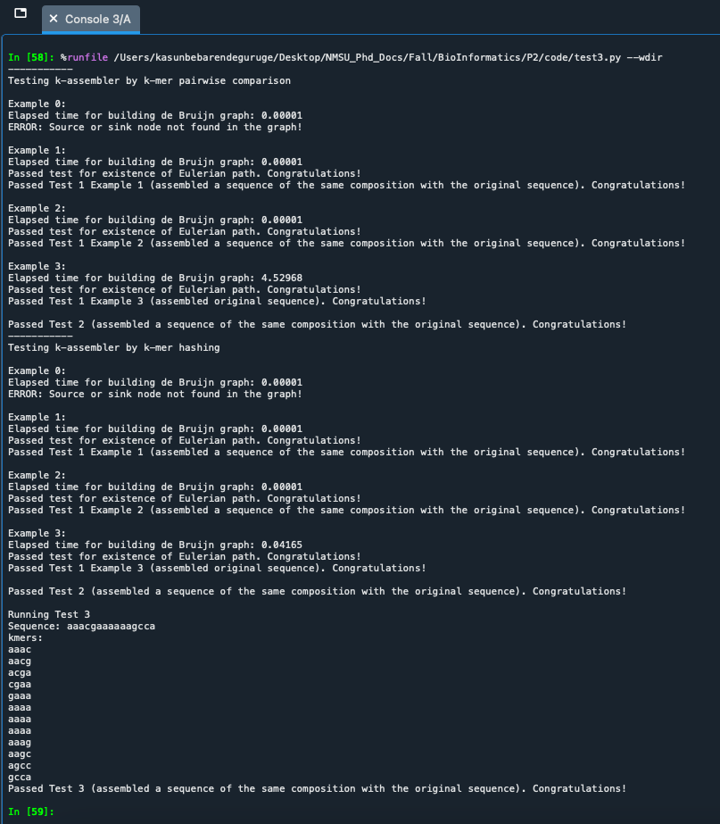

## Comparison

```
Table: Sequence Length vs. Runtime
Sequence Length      Pairwise Time (s)         Hashing Time (s)
100                  0.00036                   0.00020
500                  0.00820                   0.00096
1000                 0.03591                   0.00202
2000                 0.14258                   0.00398
5000                 0.88776                   0.00952
10000                3.52170                   0.02067
20000                13.69538                  0.03974
```

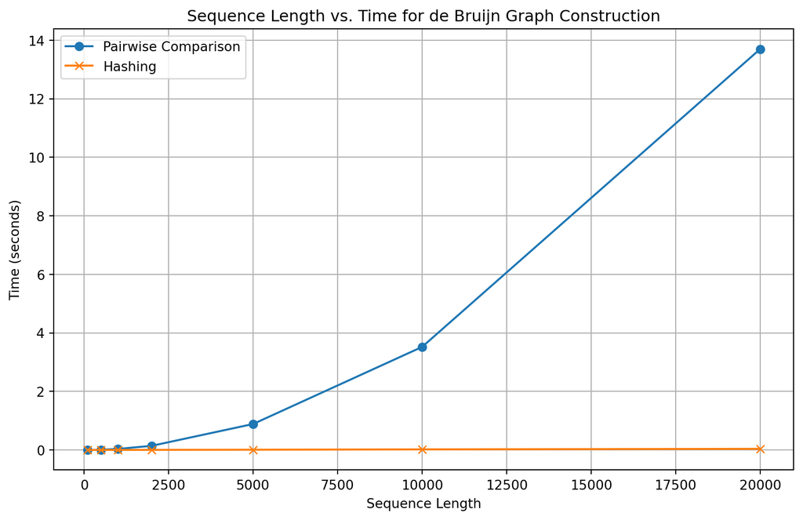

```python
import time
import random
from collections import defaultdict, deque
import matplotlib.pyplot as plt

# Helper classes and functions from the previous code
class Node:
    def __init__(self, label):
        self.label = label
        self.num_of_incoming = 0
        self.outgoing = []

def generate_random_dna_sequence(length):
    return ''.join(random.choice('ACGT') for _ in range(length))

def get_kmers(seq, k):
    return [seq[i:i+k] for i in range(len(seq) - k + 1)]

def create_deBruijn_graph_by_pairwise_comp(kmers):
    nodes = []
    node_labels = {}
    graph = defaultdict(list)

    for kmer in kmers:
        k = len(kmer)
        prefix = kmer[:k-1]
        suffix = kmer[1:]

        # Find or create the node for prefix
        prefix_node_id = None
        for i, node in enumerate(nodes):
            if node.label == prefix:
                prefix_node_id = i
                break

        if prefix_node_id is None:
            new_node = Node(prefix)
            nodes.append(new_node)
            prefix_node_id = len(nodes) - 1
            node_labels[prefix_node_id] = prefix

        # Find or create the node for suffix
        suffix_node_id = None
        for i, node in enumerate(nodes):
            if node.label == suffix:
                suffix_node_id = i
                break

        if suffix_node_id is None:
            new_node = Node(suffix)
            nodes.append(new_node)
            suffix_node_id = len(nodes) - 1
            node_labels[suffix_node_id] = suffix

        # Add edge from prefix to suffix
        nodes[prefix_node_id].outgoing.append(suffix_node_id)
        nodes[suffix_node_id].num_of_incoming += 1

    for i, node in enumerate(nodes):
        graph[i] = node.outgoing

    return graph, node_labels

class DNAHasher:
    def hash_kmer(self, kmer):
        val = 0
        for base in kmer.upper():
            val <<= 2
            if base == 'A':
                val += 0
            elif base == 'C':
                val += 1
            elif base == 'G':
                val += 2
            elif base == 'T':
                val += 3
            else:
                raise ValueError(f"Invalid nucleotide: {base}")
        return val

def create_deBruijn_graph_with_hashing(kmers):
    graph = defaultdict(list)
    node_labels = {}
    hasher = DNAHasher()

    for kmer in kmers:
        prefix = kmer[:-1]
        suffix = kmer[1:]

        prefix_hash = hasher.hash_kmer(prefix)
        suffix_hash = hasher.hash_kmer(suffix)

        node_labels[prefix_hash] = prefix
        node_labels[suffix_hash] = suffix

        graph[prefix_hash].append(suffix_hash)
        if suffix_hash not in graph:
            graph[suffix_hash] = []

    return graph, node_labels

def measure_runtime_vs_length(method, lengths, k=10):
    runtimes = []

    for length in lengths:
        seq_truth = generate_random_dna_sequence(length)
        kmers = get_kmers(seq_truth, k)

        start_time = time.time()
        if method == "k-mer pairwise comparison":
            graph, node_labels = create_deBruijn_graph_by_pairwise_comp(kmers)
        elif method == "k-mer hashing":
            graph, node_labels = create_deBruijn_graph_with_hashing(kmers)
        else:
            raise ValueError("Unknown method!")

        elapsed_time = time.time() - start_time
        runtimes.append(elapsed_time)

    return runtimes

def plot_length_vs_time(lengths, pairwise_times, hashing_times):
    plt.figure(figsize=(10, 6))
    plt.plot(lengths, pairwise_times, label="Pairwise Comparison", marker='o')
    plt.plot(lengths, hashing_times, label="Hashing", marker='x')
    plt.xlabel("Sequence Length")
    plt.ylabel("Time (seconds)")
    plt.title("Sequence Length vs. Time for de Bruijn Graph Construction")
    plt.legend()
    plt.grid(True)
    plt.show()

def run_length_vs_time_test():
    lengths = [100, 500, 1000, 2000, 5000, 10000, 20000]  # Different sequence lengths
    pairwise_times = measure_runtime_vs_length("k-mer pairwise comparison", lengths)
    hashing_times = measure_runtime_vs_length("k-mer hashing", lengths)

    print("\nTable: Sequence Length vs. Runtime")
    print("{:<20} {:<25} {:<25}".format("Sequence Length", "Pairwise Time (s)", "Hashing Time (s)"))
    for length, pt, ht in zip(lengths, pairwise_times, hashing_times):
        print(f"{length:<20} {pt:<25.5f} {ht:<25.5f}")

    plot_length_vs_time(lengths, pairwise_times, hashing_times)

if __name__ == "__main__":
    run_length_vs_time_test()
```

# Discussion

The results show a clear distinction in performance between the two methods. The pairwise comparison method exhibits quadratic growth in runtime as the sequence length increases, while the hashing method demonstrates linear growth. This makes hashing more efficient for large-scale DNA assembly tasks. The results also highlight that hashing is consistently faster across all sequence lengths tested, reinforcing its suitability for bioinformatics applications.

# (k-d)-mer sequence assembler

```python
from collections import defaultdict, deque
import time

class DNAHasher:
    def hash_kmer(self, kmer):
        """Generate a hash for the DNA k-mer."""
        val = 0
        for base in kmer.upper():
            val <<= 2
            if base == 'A':
                val += 0
            elif base == 'C':
                val += 1
            elif base == 'G':
                val += 2
            elif base == 'T':
                val += 3
            else:
                raise ValueError(f"Invalid nucleotide: {base}")
        return val

def get_kdmers(seq, k, d):
    """
    Generate all (k, d)-mers from the given sequence.
    A (k, d)-mer is defined as two k-mers separated by distance d.
    """
    kdmers = []
    for i in range(len(seq) - 2 * k - d + 1):
        prefix_kmer = seq[i:i + k]
        suffix_kmer = seq[i + k + d:i + 2 * k + d]
        kdmers.append((prefix_kmer, suffix_kmer))
    return kdmers

def create_paired_deBruijn_graph(kdmers):
    """
    Constructs a paired de Bruijn graph from (k, d)-mers.
    """
    graph = defaultdict(list)
    node_labels = {}
    hasher = DNAHasher()

    for prefix_kmer, suffix_kmer in kdmers:
        prefix = (prefix_kmer[:-1], suffix_kmer[:-1])
        suffix = (prefix_kmer[1:], suffix_kmer[1:])

        # Hash the nodes for graph representation
        prefix_hash = (hasher.hash_kmer(prefix[0]), hasher.hash_kmer(prefix[1]))
        suffix_hash = (hasher.hash_kmer(suffix[0]), hasher.hash_kmer(suffix[1]))

        node_labels[prefix_hash] = prefix
        node_labels[suffix_hash] = suffix

        # Add the edge to the graph
        graph[prefix_hash].append(suffix_hash)

    return graph, node_labels

def find_all_Eulerian_paths(graph):
    """
    Find all possible Eulerian paths in the graph using backtracking.
    """
    paths = []
    start_node = next(iter(graph))

    def backtrack(path, temp_graph):
        current_node = path[-1]
        if all(not temp_graph[node] for node in temp_graph):
            paths.append(list(path))
            return

        if temp_graph[current_node]:
            for next_node in temp_graph[current_node][:]:
                temp_graph[current_node].remove(next_node)
                path.append(next_node)
                backtrack(path, temp_graph)
                path.pop()
                temp_graph[current_node].append(next_node)

    temp_graph = defaultdict(list, {k: v[:] for k, v in graph.items()})
    backtrack([start_node], temp_graph)
    return paths

def reconstruct_strings_from_path(path, node_labels, k, d):
    """
    Reconstruct PrefixString and SuffixString from the Eulerian path.
    """
    prefix_string = node_labels[path[0]][0]
    suffix_string = node_labels[path[0]][1]

    for node in path[1:]:
        prefix_string += node_labels[node][0][-1]
        suffix_string += node_labels[node][1][-1]

    return prefix_string, suffix_string

def check_consistency(PrefixString, SuffixString, k, d):
    """
    Check if PrefixString and SuffixString are consistent, i.e., they overlap perfectly.
    """
    overlap_len = k + d
    for i in range(overlap_len, len(PrefixString)):
        if PrefixString[i] != SuffixString[i - overlap_len]:
            return False
    return True

def assemble_genome_from_paired_reads(seq, k, d):
    """
    Main function to reconstruct the genome from (k, d)-mers.
    """
    # Step 1: Generate (k, d)-mers from the input sequence
    kdmers = get_kdmers(seq, k, d)
    print(f"(k, d)-mers for k={k}, d={d}:")
    for kmer in kdmers:
        print(f"({kmer[0]} | {kmer[1]})")

    # Step 2: Construct paired de Bruijn graph
    graph, node_labels = create_paired_deBruijn_graph(kdmers)
    print("\nPaired de Bruijn Graph constructed.")

    # Step 3: Find all Eulerian paths in the paired de Bruijn graph
    print("\nFinding all Eulerian paths...")
    paths = find_all_Eulerian_paths(graph)

    # Iterate through all paths to find a consistent one
    for attempt, path in enumerate(paths, 1):
        # Step 4: Reconstruct PrefixString and SuffixString from the path
        PrefixString, SuffixString = reconstruct_strings_from_path(path, node_labels, k, d)

        # Step 5: Check if PrefixString and SuffixString are consistent
        if check_consistency(PrefixString, SuffixString, k, d):
            print(f"\n\nConsistent Eulerian Path found after {len(paths)} attempt(s).")
            print(f"Final Path: ", end="")
            for node in path:
                print(node_labels[node], end=" -> ")
            print("\n")

            print("PrefixString and SuffixString are consistent.")
            genome = PrefixString + SuffixString[-(k + d):]
            print(f"Reconstructed Genome: {genome}")
            return

    print("\nNo consistent genome found after exploring all Eulerian paths.")

# Example test
seq = "AGCAGCTGCTGCA"
k = 2
d = 1

print(f"Original Sequence: {seq}")
assemble_genome_from_paired_reads(seq, k, d)
```

```
Original Sequence: AGCAGCTGCTGCA
(k, d)-mers for k=2, d=1:
(AG | AG)
(GC | GC)
(CA | CT)
(AG | TG)
(GC | GC)
(CT | CT)
(TG | TG)
(GC | GC)
(CT | CA)

Paired de Bruijn Graph constructed.

Finding all Eulerian paths...


Consistent Eulerian Path found after 12 attempt(s).
Final Path: ('A', 'A') -> ('G', 'G') -> ('C', 'C') -> ('A', 'T') -> ('G', 'G') -> ('C', 'C') -> ('T', 'T') -> ('G', 'G') -> ('C', 'C') -> ('T', 'A') ->

PrefixString and SuffixString are consistent.
Reconstructed Genome: AGCAGCTGCTGCA
```

## Methods Overview

This section provides a high-level overview of the algorithms, data structures, and complexities involved in reconstructing genomes from (k, d)-mers using paired De Bruijn graphs. The process is structured into multiple steps, each contributing to different aspects of genome assembly.

### 1. (k, d)-mer Generation

**Purpose:** Extracts all possible (k, d)-mers from a given DNA sequence, where each (k, d)-mer consists of two overlapping k-mers separated by a gap of length d.

- **Algorithm:** Iterates through the input sequence, generating (k, d)-mers by splitting it into two overlapping k-mers at a distance d.
- **Complexity:**
  - **Time Complexity:** O(n), where n is the length of the input sequence, as each nucleotide is scanned once.
  - **Space Complexity:** O(n), proportional to the number of (k, d)-mers generated.

### 2. Paired De Bruijn Graph Construction

**Purpose:** Constructs a paired De Bruijn graph from the generated (k, d)-mers, where nodes represent (k-1, k-1)-mers and edges represent connections between these nodes.

- **Algorithm:**
  - For each (k, d)-mer, derive its prefix and suffix to form nodes in the graph.
  - Edges connect these nodes to create a directed graph representation.
- **Data Structures:**
  - The graph is represented using an adjacency list.
  - Hashing is used for node representation, ensuring fast lookups and storage efficiency.
- **Complexity:**
  - **Time Complexity:** O(m), where m is the number of (k, d)-mers, as each (k, d)-mer is processed once.
  - **Space Complexity:** O(m), for storing the nodes and edges.

### 3. Finding All Eulerian Paths

**Purpose:** Finds all possible Eulerian paths in the paired De Bruijn graph, representing potential solutions for genome assembly.

- **Algorithm:** Uses backtracking to explore all possible Eulerian paths in the graph. The algorithm keeps track of visited edges and paths until all edges are explored.
- **Complexity:**
  - **Time Complexity:** O(P * (V + E)), where P is the number of possible Eulerian paths, V is the number of nodes, and E is the number of edges in the graph.
  - **Space Complexity:** O(E * P), due to the storage of multiple paths during the traversal process.

### 4. Reconstructing Prefix and Suffix Strings

**Purpose:** Reconstructs the PrefixString and SuffixString from the Eulerian path. These strings represent the overlapping sequences derived from the path in the paired De Bruijn graph.

- **Algorithm:** Traverses the path, appending characters from the nodes to form two strings: the prefix and the suffix.
- **Complexity:**
  - **Time Complexity:** O(m), as each node in the Eulerian path is visited once.
  - **Space Complexity:** O(n), where n is the length of the assembled sequence.

### 5. Checking Consistency of Prefix and Suffix Strings

**Purpose:** Verifies whether the prefix and suffix strings overlap correctly, ensuring a consistent assembly of the genome.

- **Algorithm:** Compares the overlapping portions of the prefix and suffix strings to confirm a perfect match.
- **Complexity:**
  - **Time Complexity:** O(n), where n is the length of the overlap being checked.
  - **Space Complexity:** O(1), since no additional data structures are required.

### 6. Genome Assembly

**Purpose:** Assembles the final genome from the consistent prefix and suffix strings.

- **Algorithm:** If the prefix and suffix strings match perfectly, the genome is assembled by concatenating them with an overlap of length k + d.
- **Error Handling:**
  - If the strings do not overlap perfectly, the algorithm attempts another Eulerian path, repeating the process until a consistent genome is found or all possible paths are explored.
- **Complexity:**
  - **Time Complexity:** O(P * (m + n)), where P is the number of possible paths, m is the number of (k, d)-mers, and n is the length of the assembled genome.
  - **Space Complexity:** O(n), as it stores the assembled genome.

### Overall Code Structure

The entire process is built around a sequential execution of key steps:

1. Extract (k, d)-mers from the given sequence.
2. Construct the paired De Bruijn graph using the generated (k, d)-mers.
3. Find all possible Eulerian paths in the graph.
4. Reconstruct the PrefixString and SuffixString from each path.
5. Check the consistency of the prefix and suffix strings.
6. Assemble the genome if a consistent overlap is found; otherwise, try another Eulerian path.

The algorithm terminates when a consistent genome is found or when all Eulerian paths have been explored without success.

### Efficiency

- The code efficiently handles the construction and traversal of the paired De Bruijn graph using hashing and optimized graph traversal techniques.
- It scales with the number of (k, d)-mers and the size of the graph, making it suitable for genome assembly tasks, even when multiple Eulerian paths need to be explored.

### Summary

This implementation provides a systematic approach to genome assembly using paired De Bruijn graphs. The main challenge is ensuring that the constructed graph yields a consistent genome, which may require exploring multiple Eulerian paths. The use of hashing, backtracking, and efficient graph traversal makes this approach scalable and practical for large datasets.